# Efficient supply allocation

The success of Bolt as a ride-hailing platform depends on a marketplace or efficient matching supply and demand in real-time. There are two sides in a ride-hailing marketplace: riders (demand) and drivers (supply). One of the challenges that we aim to solve is efficient supply allocation, so riders can always get a ride and drivers have stable earnings. Knowledge about how demand changes over time and space is crucial to comprehend supply dynamics.

```python
import matplotlib.pyplot as plt
import numpy as np
import pandas as pd
import seaborn as sns

%matplotlib inline
```

```python
df = pd.read_csv("robotex5.csv")
df["start_time"] = pd.to_datetime(df["start_time"])

df.head()
```

|  | start_time | start_lat | start_lng | end_lat | end_lng | ride_value |
| --- | --- | --- | --- | --- | --- | --- |
| 0 | 2022-03-06 15:02:39.329452 | 59.407910 | 24.689836 | 59.513027 | 24.831630 | 3.51825 |
| 1 | 2022-03-10 11:15:55.177526 | 59.441650 | 24.762712 | 59.426450 | 24.783076 | 0.50750 |
| 2 | 2022-03-06 14:23:33.893257 | 59.435404 | 24.749795 | 59.431901 | 24.761588 | 0.19025 |
| 3 | 2022-03-03 09:11:59.104192 | 59.406920 | 24.659006 | 59.381093 | 24.641652 | 0.75600 |
| 4 | 2022-03-06 00:13:01.290346 | 59.434940 | 24.753641 | 59.489203 | 24.876170 | 2.27100 |

```python
print("Basic Data Info:")
df.info()
```

```
Basic Data Info:
<class 'pandas.core.frame.DataFrame'>
RangeIndex: 627210 entries, 0 to 627209
Data columns (total 6 columns):
 #   Column      Non-Null Count   Dtype
---  ------      --------------   -----
 0   start_time  627210 non-null  datetime64[ns]
 1   start_lat   627210 non-null  float64
 2   start_lng   627210 non-null  float64
 3   end_lat     627210 non-null  float64
 4   end_lng     627210 non-null  float64
 5   ride_value  627210 non-null  float64
dtypes: datetime64[ns](1), float64(5)
memory usage: 28.7 MB
```

```python
print("\nNumerical Statistics:")
print(df.describe())
```

```
Numerical Statistics:
                          start_time      start_lat      start_lng  \
count                         627210  627210.000000  627210.000000
mean   2022-03-15 19:02:27.534693632      59.428682      24.743468
min       2022-03-01 00:00:07.936317      59.321557      24.505199
25%    2022-03-09 00:03:53.773355008      59.418803      24.713140
50%    2022-03-16 08:22:42.513948160      59.432069      24.744674
75%    2022-03-22 21:30:09.320409600      59.439024      24.768115
max       2022-03-28 23:59:53.175658      59.566998      24.973743
std                              NaN       0.021764       0.056872

             end_lat        end_lng     ride_value
count  627210.000000  627210.000000  627210.000000
mean       59.397797      24.724847       2.261384
min       -37.819979    -122.453962       0.107628
25%        59.415215      24.707919       0.545250
50%        59.430697      24.744335       1.059000
75%        59.439262      24.773924       1.712000
max        61.552744     144.966110    3172.701000
std         1.392755       1.650709      44.889892
```

## Loading and Cleaning Data

This section gets the ride data ready. I load it from a CSV file, fix any missing or repeated rows and check the data types of the columns.

**Conclusions:**

I cleaned about 0.7% of the rows by removing missing values and duplicates. All columns have the correct data types.

I also remove rides outside of Europe since I assume it has low possibility to achieve that

```python
# Remove rows with missing values
print("\nNumber of rows before removing missing values:", len(df))
old_df_len = len(df)
df = df.dropna()
print("Number of rows after removing missing values:", len(df))

# Remove duplicates
print("\nNumber of rows before removing duplicates:", len(df))
df = df.drop_duplicates()
print("Number of rows after removing duplicates:", len(df))
new_df_len = len(df)
print(
    f"Initial cleanse rate: {(old_df_len - new_df_len) / new_df_len: .3f}, {old_df_len - new_df_len} rows removed"
)

# Check types of columns
for col in df.columns:
    if col == "start_time":
        assert all(isinstance(x, pd.Timestamp) for x in df[col])
    else:
        assert all(isinstance(x, float) for x in df[col])
```

```
Number of rows before removing missing values: 627210
Number of rows after removing missing values: 627210

Number of rows before removing duplicates: 627210
Number of rows after removing duplicates: 622646
Initial cleanse rate:  0.007, 4564 rows removed
```

```python
EUROPE_BOUNDS = {
    "lat_min": 35.0,  # Southernmost point
    "lat_max": 71.0,  # Northernmost point
    "lng_min": -25.0,  # Westernmost point
    "lng_max": 45.0,  # Easternmost point
}
# Check data with any of start_lat, start_lng, end_lat, end_lng outside of Europe
print("\nData with any of start_lat, start_lng, end_lat, end_lng outside of Europe:")
df_ooeu = df[
    (df["start_lat"] < EUROPE_BOUNDS["lat_min"])
    | (df["start_lat"] > EUROPE_BOUNDS["lat_max"])
    | (df["start_lng"] < EUROPE_BOUNDS["lng_min"])
    | (df["start_lng"] > EUROPE_BOUNDS["lng_max"])
    | (df["end_lat"] < EUROPE_BOUNDS["lat_min"])
    | (df["end_lat"] > EUROPE_BOUNDS["lat_max"])
    | (df["end_lng"] < EUROPE_BOUNDS["lng_min"])
    | (df["end_lng"] > EUROPE_BOUNDS["lng_max"])
]
print(df_ooeu.sample(5))
```

```
Data with any of start_lat, start_lng, end_lat, end_lng outside of Europe:
                       start_time  start_lat  start_lng    end_lat    end_lng  \
489697 2022-03-13 02:39:58.930056  59.446400  24.733662  -0.000217  -0.000016
280755 2022-03-23 02:39:58.930056  59.446400  24.733662  -0.000217  -0.000016
7014   2022-03-25 11:18:04.439941  59.398940  24.702821   0.000134  -0.000317
212289 2022-03-23 08:45:07.499000  59.414513  24.816517   0.000347   0.000385
584830 2022-03-28 18:51:09.982263  59.415123  24.798889  17.677803  83.194147

         ride_value
489697  1684.961750
280755  1684.961750
7014    1683.576500
212289  1684.311277
584830  1413.481750
```

```python
from geopy.geocoders import Nominatim


def get_country(lat, lng):
    try:
        location = geolocator.reverse(f"{lat}, {lng}")
        if not location:
            return None
        address = location.raw["address"]
        return address.get("country", None)
    except Exception as e:
        print(f"Error: {e}")
        return None


def check_order(df):
    for i, row in df.iterrows():
        print(f"ride_value: {row['ride_value']}")
        start_country_code = get_country(row["start_lat"], row["start_lng"])
        end_country_code = get_country(row["end_lat"], row["end_lng"])
        print(f"Row {i}: {start_country_code} -> {end_country_code}")
        print("-" * 50)


# Sample df_ooeu and check it's start and end country
geolocator = Nominatim(user_agent="robotex5")
sample_ooeu = df_ooeu.sample(5)
check_order(sample_ooeu)
```

```
ride_value: 1633.55825
Row 497900: Eesti -> United States
--------------------------------------------------
ride_value: 1684.96175
Error: Must be a coordinate pair or Point
Row 489697: Eesti -> None
--------------------------------------------------
ride_value: 1684.06975
Row 117666: Eesti -> None
--------------------------------------------------
ride_value: 1683.5765
Row 7014: Eesti -> None
--------------------------------------------------
ride_value: 1685.043
Row 151377: Eesti -> None
--------------------------------------------------
```

```python
# remove df_ooeu from df
print("\nNumber of rows before removing data outside of Europe:", len(df))
df = df.drop(df_ooeu.index)
print("Number of rows after removing data outside of Europe:", len(df))
```

```
Number of rows before removing data outside of Europe: 622646
Number of rows after removing data outside of Europe: 622334
```

## EDA

Here, I look at the data to spot patterns. I make maps of where rides start and end, check ride values, and see how demand changes by hour. This helps figure out where drivers should go.

Sampled heatmaps revealed hotspots near the city center.

This shows drivers can’t just stay put, they need to move to busy spots, which my solution will guide them to.

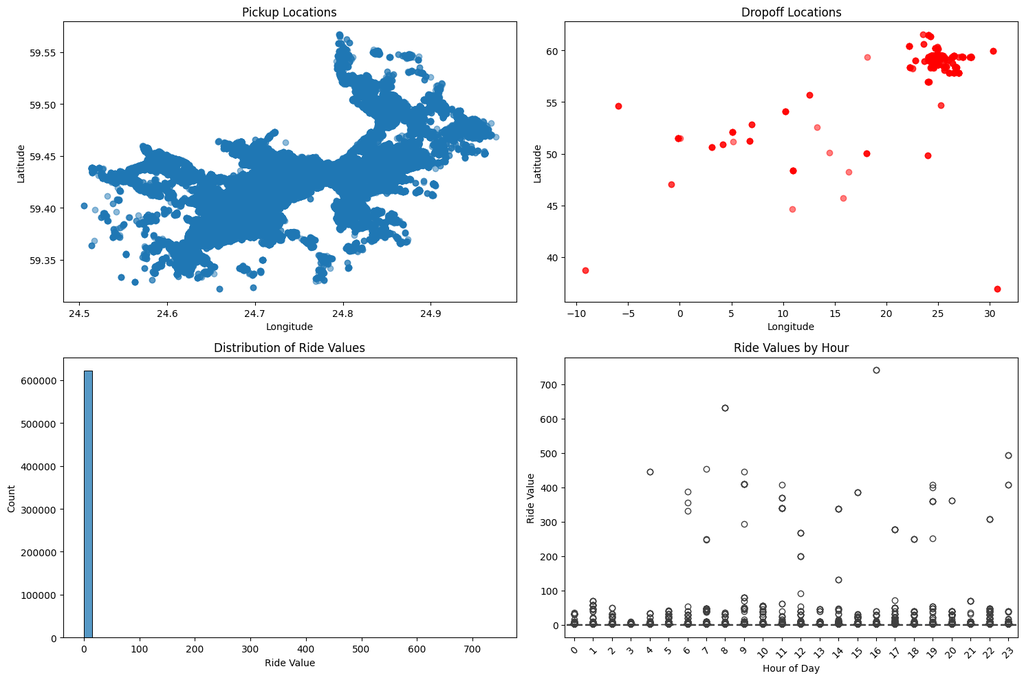

```python
# Visualizations
plt.figure(figsize=(15, 10))

# Pickup locations
plt.subplot(221)
plt.scatter(df["start_lng"], df["start_lat"], alpha=0.5)
plt.title("Pickup Locations")
plt.xlabel("Longitude")
plt.ylabel("Latitude")

# Dropoff locations
plt.subplot(222)
plt.scatter(df["end_lng"], df["end_lat"], alpha=0.5, color="red")
plt.title("Dropoff Locations")
plt.xlabel("Longitude")
plt.ylabel("Latitude")

# Ride value distribution
plt.subplot(223)
sns.histplot(df["ride_value"], bins=50)
plt.title("Distribution of Ride Values")
plt.xlabel("Ride Value")
plt.ylabel("Count")


# Time analysis
df["hour"] = df["start_time"].dt.hour

plt.subplot(224)
sns.boxplot(x="hour", y="ride_value", data=df)
plt.title("Ride Values by Hour")
plt.xlabel("Hour of Day")
plt.ylabel("Ride Value")
plt.xticks(rotation=45)

plt.tight_layout()
plt.show()
```

#### Check if there are some possible outliers in the ride_value column

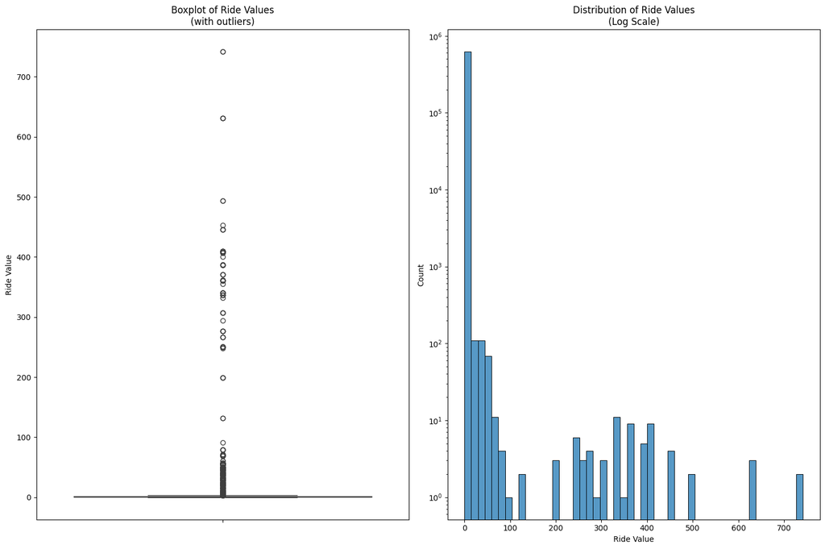

```python
plt.figure(figsize=(15, 10))

# Original distribution
plt.subplot(121)
sns.boxplot(y=df["ride_value"])
plt.title("Boxplot of Ride Values\n(with outliers)")
plt.ylabel("Ride Value")

plt.subplot(122)
# Make count as log scale in histogram
g = sns.histplot(df["ride_value"], bins=50)
g.set_yscale("log")

plt.title("Distribution of Ride Values\n(Log Scale)")
plt.xlabel("Ride Value")
plt.ylabel("Count")


plt.tight_layout()
plt.show()
```

```python
# Basic statistics of ride_value
print("Ride Value Statistics:")
print(df["ride_value"].describe([0.01, 0.05, 0.25, 0.5, 0.75, 0.95, 0.99]))
```

```
Ride Value Statistics:
count    622334.000000
mean          1.306655
std           4.156650
min           0.107628
1%            0.125000
5%            0.186293
25%           0.545000
50%           1.058500
75%           1.710750
95%           3.032000
99%           4.243168
max         741.616250
Name: ride_value, dtype: float64
```

```python
# Calculate potential outliers
# naive way to set upper bound
upper_bound = 100

outliers = df[df["ride_value"] > upper_bound]
print(f"\nNumber of outliers: {len(outliers)}")
print(f"Percentage of outliers: {(len(outliers) / old_df_len) * 100:.2f}%")
print("\nTop 10 highest ride values:")
print(df["ride_value"].nlargest(10))

sample_outlier = outliers.sample(5)
check_order(sample_outlier)
```

```
Number of outliers: 68
Percentage of outliers: 0.01%

Top 10 highest ride values:
174235    741.616250
481260    741.611661
182383    631.098008
216176    631.089500
394958    631.089500
7421      493.674250
64788     493.674250
469614    452.815750
580938    445.786750
266472    445.507500
Name: ride_value, dtype: float64
ride_value: 360.62144142919567
Row 84624: Eesti -> Deutschland
--------------------------------------------------
ride_value: 370.508
Row 61973: Eesti -> België / Belgique / Belgien
--------------------------------------------------
ride_value: 250.141
Row 357504: Eesti -> Deutschland
--------------------------------------------------
ride_value: 250.84825
Row 58443: Eesti -> Deutschland
--------------------------------------------------
ride_value: 250.141
Row 562749: Eesti -> Deutschland
--------------------------------------------------
```

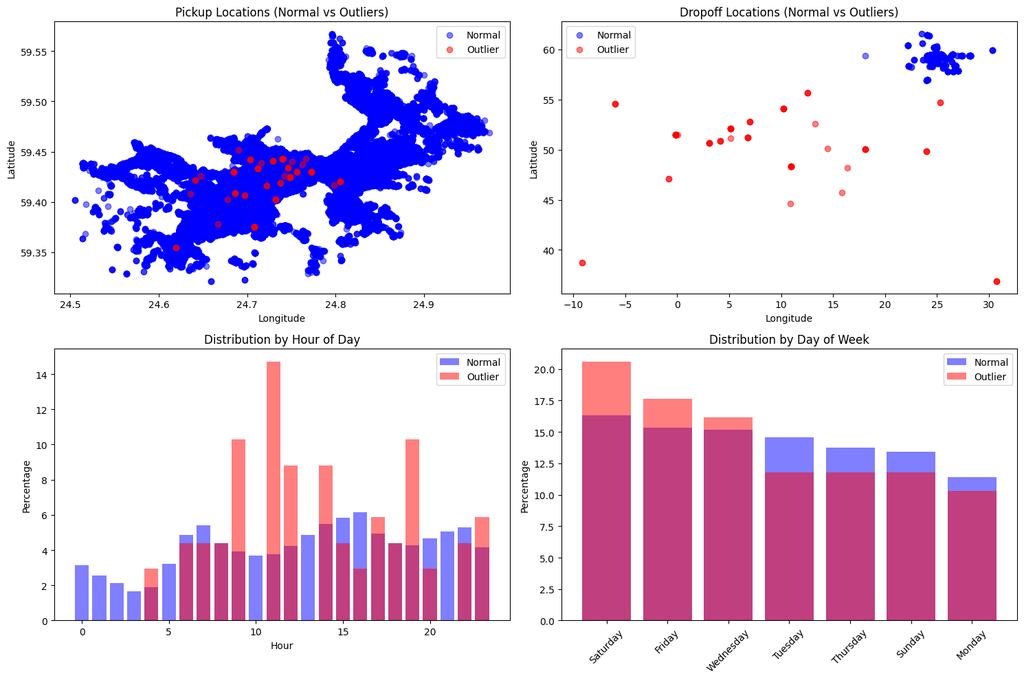

```python
# Add time components
df["hour"] = df["start_time"].dt.hour
df["day_of_week"] = df["start_time"].dt.day_name()
# df["date"] = df["start_time"].dt.date

# Create outlier flag
df["is_outlier"] = df["ride_value"] > upper_bound

# 1. Spatial Distribution
plt.figure(figsize=(15, 10))

# Pickup locations
plt.subplot(221)
plt.scatter(
    df[~df["is_outlier"]]["start_lng"],
    df[~df["is_outlier"]]["start_lat"],
    alpha=0.5,
    label="Normal",
    color="blue",
)
plt.scatter(
    df[df["is_outlier"]]["start_lng"],
    df[df["is_outlier"]]["start_lat"],
    alpha=0.5,
    label="Outlier",
    color="red",
)
plt.title("Pickup Locations (Normal vs Outliers)")
plt.xlabel("Longitude")
plt.ylabel("Latitude")
plt.legend()

# Dropoff locations
plt.subplot(222)
plt.scatter(
    df[~df["is_outlier"]]["end_lng"],
    df[~df["is_outlier"]]["end_lat"],
    alpha=0.5,
    label="Normal",
    color="blue",
)
plt.scatter(
    df[df["is_outlier"]]["end_lng"],
    df[df["is_outlier"]]["end_lat"],
    alpha=0.5,
    label="Outlier",
    color="red",
)
plt.title("Dropoff Locations (Normal vs Outliers)")
plt.xlabel("Longitude")
plt.ylabel("Latitude")
plt.legend()

# 2. Temporal Distribution
# By hour
plt.subplot(223)
outlier_by_hour = df[df["is_outlier"]]["hour"].value_counts(normalize=True) * 100
normal_by_hour = df[~df["is_outlier"]]["hour"].value_counts(normalize=True) * 100

plt.bar(normal_by_hour.index, normal_by_hour, alpha=0.5, label="Normal", color="blue")
plt.bar(outlier_by_hour.index, outlier_by_hour, alpha=0.5, label="Outlier", color="red")
plt.title("Distribution by Hour of Day")
plt.xlabel("Hour")
plt.ylabel("Percentage")
plt.legend()

# By day of week
plt.subplot(224)
outlier_by_day = df[df["is_outlier"]]["day_of_week"].value_counts(normalize=True) * 100
normal_by_day = df[~df["is_outlier"]]["day_of_week"].value_counts(normalize=True) * 100

plt.bar(
    range(len(normal_by_day)), normal_by_day, alpha=0.5, label="Normal", color="blue"
)
plt.bar(
    range(len(outlier_by_day)), outlier_by_day, alpha=0.5, label="Outlier", color="red"
)
plt.title("Distribution by Day of Week")
plt.xticks(range(len(normal_by_day)), normal_by_day.index, rotation=45)
plt.ylabel("Percentage")
plt.legend()

plt.tight_layout()
plt.show()
```

```python
df = df[~df["is_outlier"]]


print("Number of rows been removed:", old_df_len - len(df))
print(f"Advance cleanse data rate, {(old_df_len - len(df)) / old_df_len: .3f}")
```

```
Number of rows been removed: 4944
Advance cleanse data rate,  0.008
```

#### Check heatmap of ride values by rush hours in a specific day

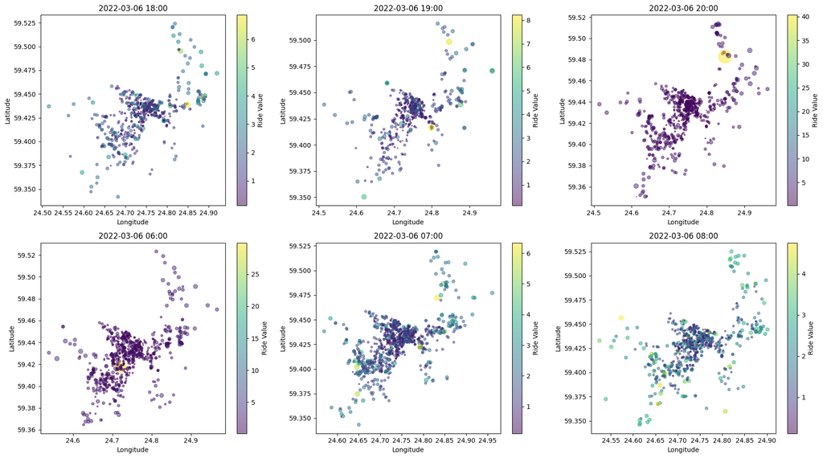

```python
def create_hourly_heatmap(filtered_df, hour, ax):
    if filtered_df.empty:
        ax.text(0.5, 0.5, f"No rides for {hour}", ha="center", va="center")
        ax.set_xlabel("Longitude")
        ax.set_ylabel("Latitude")
        ax.set_title(f"Hour {hour}")
    else:
        scatter = ax.scatter(
            filtered_df["start_lng"],  # x-axis: longitude
            filtered_df["start_lat"],  # y-axis: latitude
            c=filtered_df["ride_value"],  # Color by ride_value
            s=filtered_df["ride_value"]
            * 10,  # Size by ride_value (scale for visibility)
            cmap="viridis",  # Color scheme: yellow=high, purple=low
            alpha=0.5,  # Transparency for overlap
        )
        # Add colorbar to this axis
        plt.colorbar(scatter, ax=ax, label="Ride Value")
        # Labels and title
        ax.set_xlabel("Longitude")
        ax.set_ylabel("Latitude")
        ax.set_title(f"{hour}")


# Floor start_time to hourly precision
df["start_time_floor"] = df["start_time"].dt.floor("H")

# Define the two starting timestamps
start_time_pm = pd.Timestamp("2022-03-06 18:00:00")
start_time_am = pd.Timestamp("2022-03-06 06:00:00")

# Create a figure with 2 rows and 3 columns
fig, axes = plt.subplots(2, 3, figsize=(18, 10))  # 18 wide, 10 tall
axes = axes.flatten()  # Flatten for easy indexing

# Generate 3 hours from 6 PM
for i in range(3):
    target_time = start_time_pm + pd.Timedelta(hours=i)
    filtered_df = df[df["start_time_floor"] == target_time]
    hour_label = target_time.strftime("%Y-%m-%d %H:%M")
    create_hourly_heatmap(filtered_df, hour_label, axes[i])

# Generate 3 hours from 6 AM
for i in range(3):
    target_time = start_time_am + pd.Timedelta(hours=i)
    filtered_df = df[df["start_time_floor"] == target_time]
    hour_label = target_time.strftime("%Y-%m-%d %H:%M")
    create_hourly_heatmap(filtered_df, hour_label, axes[i + 3])

# Adjust layout to prevent overlap
plt.tight_layout()
plt.show()
```

## Coordinate Quantization (Clustering)

I group pickup spots into zones using a method called K-means. It’s like drawing circles around busy areas in Tallinn. I picked 12 zones after testing—it’s enough to cover the city without being too complicated.

**Conclusion:** The 12 zones split Tallinn into manageable chunks, with some areas busier than others. This lets us focus drivers on high-demand spots instead of guessing.

```python
from sklearn.cluster import KMeans
from sklearn.metrics import silhouette_score
from sklearn.preprocessing import StandardScaler


def prepare_coordinates(df, lat: str, lng: str):
    # Extract start coordinates
    start_coords = df[[lat, lng]].values

    # # Extract end coordinates
    # end_coords = df[["end_lat", "end_lng"]].values

    # Combine unique of start and end coords into a single array
    # all_coords = np.unique(np.vstack((start_coords, end_coords)), axis=0)
    uniq_coords = np.unique(start_coords, axis=0)
    return uniq_coords


# Perform K-means clustering
def perform_kmeans(coordinates, n_clusters=3):
    # Standardize the data
    scaler = StandardScaler()
    scaled_coordinates = scaler.fit_transform(coordinates)

    # Fit K-means
    kmeans = KMeans(
        n_clusters=n_clusters,
        init="k-means++",
        n_init=3,
        max_iter=300,
        tol=1e-4,
        random_state=42,
    )
    cluster_labels = kmeans.fit_predict(scaled_coordinates)

    # Get cluster centers (transform back to original scale)
    cluster_centers = scaler.inverse_transform(kmeans.cluster_centers_)

    return cluster_labels, cluster_centers, scaler, kmeans


# Visualize the results
def visualize_clusters(coordinates, labels, centers):
    plt.figure(figsize=(10, 8))

    # Plot all points
    for cluster_num in range(len(centers)):
        cluster_points = coordinates[labels == cluster_num]
        plt.scatter(
            cluster_points[:, 1],  # longitude
            cluster_points[:, 0],  # latitude
            s=50,
            alpha=0.7,
            label=f"Cluster {cluster_num}",
        )

    # Plot cluster centers
    plt.scatter(
        centers[:, 1],  # longitude
        centers[:, 0],  # latitude
        s=200,
        marker="X",
        c="red",
        label="Centroids",
    )

    plt.title("K-means Clustering of Ride-Hailing Start and End Points")
    plt.xlabel("Longitude")
    plt.ylabel("Latitude")
    plt.legend()
    plt.grid(True, alpha=0.3)

    # Save the figure
    # plt.savefig('tallinn_ride_clusters.png')
    plt.show()
```

```python
# Calculate optimal number of clusters using the Elbow method
def find_optimal_clusters(coordinates, min_clusters=8, max_clusters=20, stride=4):
    scaled_coordinates = StandardScaler().fit_transform(coordinates)
    inertias, silhouette_scores = [], []

    for k in range(min_clusters, max_clusters + 1, stride):
        print(f"Calculating for k={k}")
        kmeans = KMeans(
            n_clusters=k,
            init="k-means++",
            n_init=3,
            random_state=42,
        )
        cluster_labels = kmeans.fit_predict(scaled_coordinates)
        inertias.append(kmeans.inertia_)
        sample_silhouette_value = silhouette_score(
            scaled_coordinates, cluster_labels, sample_size=int(len(coordinates) * 0.1)
        )
        silhouette_scores.append(sample_silhouette_value)

    return inertias, silhouette_scores
```

```
Combined coordinates shape: (352100, 2)
Calculating for k=8
Calculating for k=12
Calculating for k=16
Calculating for k=20
Calculating for k=24
Calculating for k=28
Calculating for k=32
Calculating for k=36
Calculating for k=40
Calculating for k=44
Calculating for k=48
Calculating for k=52
Calculating for k=56
Calculating for k=60
Calculating for k=64
```

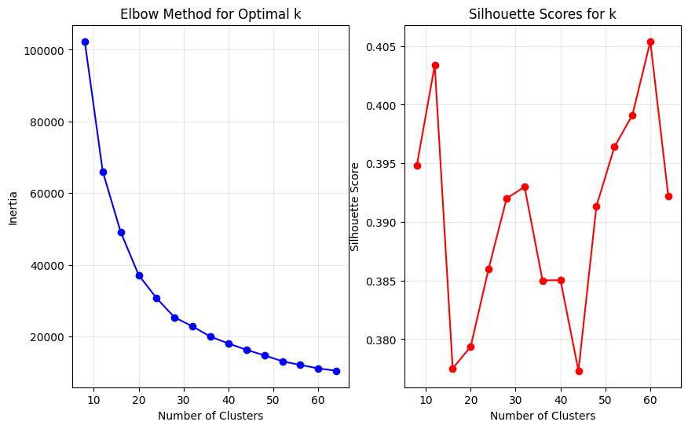

```python
# Prepare (start) coordinates
all_coords = prepare_coordinates(df, "start_lat", "start_lng")
print(f"Combined coordinates shape: {all_coords.shape}")

min_clusters, max_clusters, stride = 8, 64, 4
inertias, silhouette_scores = find_optimal_clusters(
    all_coords, min_clusters, max_clusters, stride
)
# Plot the elbow curve and silhouette scores
plt.figure(figsize=(10, 6))
plt.subplot(1, 2, 1)
plt.plot(range(min_clusters, max_clusters + 1, stride), inertias, "bo-")
plt.xlabel("Number of Clusters")
plt.ylabel("Inertia")
plt.title("Elbow Method for Optimal k")
plt.grid(True, alpha=0.3)
# plt.savefig('elbow_method.png')

plt.subplot(1, 2, 2)
plt.plot(range(min_clusters, max_clusters + 1, stride), silhouette_scores, "ro-")
plt.xlabel("Number of Clusters")
plt.ylabel("Silhouette Score")
plt.title("Silhouette Scores for k")
plt.grid(True, alpha=0.3)
# plt.savefig('silhouette_scores.png')

plt.show()
```

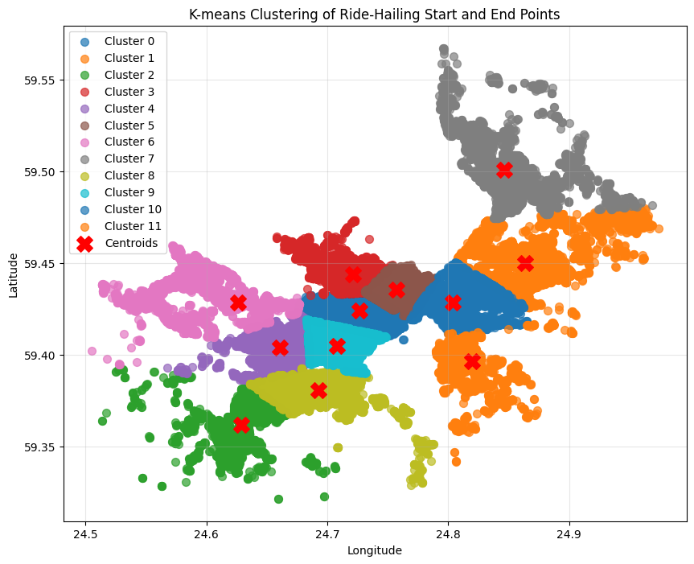

```
Cluster 0:
  Center: Lat 59.423885, Lng 24.726626
  Size: 51619 points (14.7% of total)

Cluster 1:
  Center: Lat 59.449706, Lng 24.863786
  Size: 20909 points (5.9% of total)

Cluster 2:
  Center: Lat 59.361932, Lng 24.629215
  Size: 5076 points (1.4% of total)

Cluster 3:
  Center: Lat 59.443716, Lng 24.721274
  Size: 43920 points (12.5% of total)

Cluster 4:
  Center: Lat 59.403967, Lng 24.661123
  Size: 22597 points (6.4% of total)

Cluster 5:
  Center: Lat 59.435231, Lng 24.757556
  Size: 114777 points (32.6% of total)

Cluster 6:
  Center: Lat 59.428277, Lng 24.626179
  Size: 11767 points (3.3% of total)

Cluster 7:
  Center: Lat 59.500577, Lng 24.846040
  Size: 8745 points (2.5% of total)

Cluster 8:
  Center: Lat 59.380648, Lng 24.692926
  Size: 9711 points (2.8% of total)

Cluster 9:
  Center: Lat 59.404730, Lng 24.707919
  Size: 28675 points (8.1% of total)

Cluster 10:
  Center: Lat 59.428194, Lng 24.803944
  Size: 29409 points (8.4% of total)

Cluster 11:
  Center: Lat 59.396550, Lng 24.820032
  Size: 4895 points (1.4% of total)
```

```python
# Perform clustering
n_clusters = 12  # From the elbow method and silhouette scores
labels, centers, scaler, kmeans = perform_kmeans(all_coords, n_clusters)

# Visualize results
visualize_clusters(all_coords, labels, centers)

# Print cluster information
for i, center in enumerate(centers):
    cluster_size = np.sum(labels == i)
    percentage = 100 * cluster_size / len(labels)
    print(f"Cluster {i}:")
    print(f"  Center: Lat {center[0]:.6f}, Lng {center[1]:.6f}")
    print(f"  Size: {cluster_size} points ({percentage:.1f}% of total)")
    print()
```

```python
# Create coordinate to cluster hashmap
coord_cluster_map = {
    tuple(coord): cluster for coord, cluster in zip(all_coords, labels)
}
```

```python
# Create time series data with start_time, start_alt, start_lng, ride_value
ts_df = df[["start_time", "start_lat", "start_lng", "ride_value"]].copy()

# Create cluster column by coord_cluster_map[(start_lat, start_lng)]
ts_df["cluster"] = ts_df.apply(
    lambda x: coord_cluster_map[(x["start_lat"], x["start_lng"])], axis=1
)
```

### Create multiple df grouped by cluster

If our goal is Maximize driver earnings and ensure riders get rides, aggregate ride value summation is likely better then average.

It tells you the total value drivers could capture in an hour, guiding them to busy, high-value areas.

```python
cluster_dfs = []
for cluster_num in range(n_clusters):
    cluster_df = ts_df[ts_df["cluster"] == cluster_num]
    # sort by start_time
    cluster_df = cluster_df.sort_values("start_time")
    # Extract hour from start_time
    cluster_df["hour"] = cluster_df["start_time"].dt.floor("H")

    # Group by hour and aggregate ride_value by summation
    cluster_df = cluster_df.groupby("hour")["ride_value"].sum().reset_index()

    # Sort by time
    cluster_df = cluster_df.sort_values("hour")

    cluster_df = cluster_df.reset_index(drop=True)

    # add missing hours with average value (kind of noise)
    min_hour = cluster_df["hour"].min()
    max_hour = cluster_df["hour"].max()
    all_hours = pd.date_range(min_hour, max_hour, freq="H")
    cluster_df = cluster_df.set_index("hour")
    cluster_df = cluster_df.reindex(
        all_hours, fill_value=np.mean(cluster_df["ride_value"])
    )

    cluster_df = cluster_df.reset_index()
    cluster_df = cluster_df.rename(columns={"index": "hour"})
    # create new df with hour and ride_value
    # keep only hour and ride_value columns
    cluster_df = cluster_df[["hour", "ride_value"]]
    # cluster_df = pd.DataFrame(
    #     {"hour": cluster_df["hour"], "ride_value": cluster_df["ride_value"]}
    # )

    assert len(cluster_df) == len(all_hours)
    cluster_dfs.append(cluster_df)
```

## Train ride-value forecasting model

This part builds a tool to guess future rides in each zone.

I use ARIMA, which looks at past rides to predict the next few hours. Each zone gets its own prediction, tested to make sure it’s decent.

**Conclusion:** The ARIMA models predict ride values pretty well. Drivers can use these forecasts to know where rides will pop up next, keeping them busy.

```python
import json
import os
import pickle
import warnings
from collections import defaultdict
from itertools import product

from sklearn.metrics import mean_absolute_error, mean_squared_error
from sklearn.model_selection import TimeSeriesSplit
from statsmodels.tools.sm_exceptions import ConvergenceWarning
from statsmodels.tsa.arima.model import ARIMA

warnings.simplefilter("ignore", ConvergenceWarning)

# Define parameters for cross-validation
HOURS_IN_DAY = 24
DAYS_FOR_INITIAL_TRAINING = 14  # Days of training data
DAYS_FOR_VALIDATION = 3  # Validate on 3 day at a time
TEST_DAYS = 3  # Days for final testing
```

```python
def save_model(model, filepath, overwrite=True):
    # Check if file exists and overwrite is False
    if os.path.exists(filepath) and not overwrite:
        print(f"File {filepath} already exists. Set overwrite=True to replace it.")

    # Create directory if it doesn't exist
    directory = os.path.dirname(filepath)
    if directory and not os.path.exists(directory):
        os.makedirs(directory)

    try:
        with open(filepath, "wb") as f:
            pickle.dump(model, f)
        print(f"Model successfully saved to {filepath}")

    except Exception as e:
        print(f"Error saving model: {str(e)}")


def save_train_last_date(results, dir_pth):
    # Save train_last_date for each cluster into json
    train_last_dates = {
        i: res["base_model"]["train_last_date"].strftime("%Y-%m-%d %H:%M:%S")
        for i, res in enumerate(results)
    }
    with open(f"{dir_pth}/train_last_dates.json", "w") as f:
        json.dump(train_last_dates, f)


def load_train_last_date(dir_pth):
    # Load last_train_dates json
    with open(f"{dir_pth}/train_last_dates.json", "r") as f:
        last_train_dates = json.load(f)
        cluster_train_last_dates = {
            int(k): pd.to_datetime(v) for k, v in last_train_dates.items()
        }
    return cluster_train_last_dates
```

```python
def arima_single_train(cluster_id, df, save_dir, p=24, q=1, d=24):
    result = {}

    # Base model (no additional features)
    y = df["ride_value"]
    test_size_hours = TEST_DAYS * HOURS_IN_DAY
    train = y.iloc[:-test_size_hours].copy()
    test = y.iloc[-test_size_hours:].copy()
    train_last_date = df["hour"].iloc[len(train) - 1]
    # train_size_idx = int(len(y) * train_size)
    # train, test = y[:train_size_idx], y[train_size_idx:]

    try:
        model = ARIMA(train, order=(p, q, d))
        model_fit = model.fit()

        save_model(model_fit, f"{save_dir}/cluster{cluster_id}_arima.pkl")

        predictions = model_fit.forecast(steps=test_size_hours)
        mae = mean_absolute_error(test, predictions)
        rmse = np.sqrt(mean_squared_error(test, predictions))
        result["base_model"] = {
            "mae": mae,
            "rmse": rmse,
            "train_last_date": train_last_date,
            "predictions": predictions,
        }
    except Exception as e:
        result["base_model"] = {"error": str(e)}

    return result
```

```python
# Plot forecast results
def plot_forecast(cluster_idx, mae, rmse, ax, train_data, test_data, forecast):
    # Plot training data
    ax.plot(
        train_data.index, train_data, label="Training Data", color="blue", alpha=0.7
    )
    # Plot test data
    ax.plot(test_data.index, test_data, label="Actual Test Data", color="green")
    # Plot forecast
    ax.plot(test_data.index, forecast, label="Forecast", color="red", linestyle="--")

    # Format axis - only add legend to first plot
    ax.tick_params(axis="x", rotation=45)
    # if ax == axes.flatten()[0]:  # Only add legend to first subplot
    #     ax.legend(loc="best", fontsize=8)

    # Add vertical line to separate train and test
    ax.axvline(x=train_data.index[-1], color="black", linestyle="-", alpha=0.5)

    # Set title with metrics
    ax.set_title(f"Cluster {cluster_idx} (MAE: {mae:.3f}, RMSE: {rmse:.3f})")


def plot_forecasts(results, cluster_dfs):
    # Create the figure and axes grid
    n_clusters = len(cluster_dfs)
    n_cols = 3  # Use 4 columns
    n_rows = (n_clusters + n_cols - 1) // n_cols  # Calculate rows needed

    fig, axes = plt.subplots(n_rows, n_cols, figsize=(20, 5 * n_rows))
    axes = axes.flatten()  # Flatten for easier indexing

    for cluster_idx, (result, cluster_df) in enumerate(zip(results, cluster_dfs)):
        mae, rmse = result["base_model"]["mae"], result["base_model"]["rmse"]
        test_size_hours = TEST_DAYS * HOURS_IN_DAY
        y = cluster_df["ride_value"]
        train = y.iloc[:-test_size_hours].copy()
        test = y.iloc[-test_size_hours:].copy()
        plot_forecast(
            cluster_idx,
            mae,
            rmse,
            axes[cluster_idx],
            train,
            test,
            result["base_model"]["predictions"],
        )

    # Hide unused subplots
    for i in range(n_clusters, len(axes)):
        axes[i].set_visible(False)

    plt.tight_layout()
    plt.show()
```

### Cross validation

```python
def cluster_forecast_train(cluster_idx, cluster_df):
    # Prepare training/validation and test sets
    test_size_hours = TEST_DAYS * HOURS_IN_DAY
    train_val_data = cluster_df.iloc[:-test_size_hours].copy()
    # test_data = cluster_df.iloc[-test_size_hours:].copy()

    print(f"\nCV on Cluster {cluster_idx}")

    results = arima_grid_search_cv(
        data=train_val_data,
        p_values=p_values,
        d_values=d_values,
        q_values=q_values,
    )

    best_p, best_d, best_q = results["best_params"]
    print(f"\nBest ARIMA parameters: ({best_p}, {best_d}, {best_q})")
    print(f"Best validation MAE + RMSE: {results['best_score']:.4f}")
    cv_best_params[cluster_idx] = (best_p, best_d, best_q)


# Function to evaluate ARIMA model with walk-forward validation
def evaluate_arima_model(df, p, d, q):
    max_train_size = DAYS_FOR_INITIAL_TRAINING * HOURS_IN_DAY
    test_size = DAYS_FOR_VALIDATION * HOURS_IN_DAY
    tscv = TimeSeriesSplit(
        n_splits=3, max_train_size=max_train_size, test_size=test_size
    )
    mae_errs, rmse_errs = [], []
    for train_idx, val_idx in tscv.split(df):
        train_data = df.iloc[train_idx].copy()
        val_data = df.iloc[val_idx].copy()

        # Set datetime as index for ARIMA

        train_data_indexed = train_data.set_index("hour")
        train_data_indexed.index = pd.DatetimeIndex(
            train_data_indexed.index.values, freq=train_data_indexed.index.inferred_freq
        )

        # Fit ARIMA model
        model = ARIMA(train_data_indexed["ride_value"], order=(p, d, q))
        model_fit = model.fit()

        # Forecast for validation periods
        forecast = model_fit.forecast(steps=len(val_data))
        mae = mean_absolute_error(val_data["ride_value"], forecast)
        rmse = np.sqrt(mean_squared_error(val_data["ride_value"], forecast))

        mae_errs.append(mae)
        rmse_errs.append(rmse)

    return np.mean(mae_errs), np.mean(rmse_errs)


# Time series cross-validation for ARIMA
def arima_grid_search_cv(data, p_values, d_values, q_values):
    """
    Grid search for ARIMA parameters using time series cross-validation

    Returns:
    --------
    dict
        Best parameters and performance metrics
    """
    best_score = float("inf")
    best_params = None
    all_results = defaultdict(lambda: {"mae": None, "rmse": None})

    for p, d, q in product(p_values, d_values, q_values):
        mae, rmse = evaluate_arima_model(df=data, p=p, d=d, q=q)

        if mae is not None and rmse is not None:
            all_results[(p, d, q)]["mae"] = mae
            all_results[(p, d, q)]["rmse"] = rmse
            # print(f"ARIMA({p},{d},{q}) - MAE: {mae:.4f}")
            # print(f"ARIMA({p},{d},{q}) - RMSE: {rmse:.4f}")

            if mae + rmse < best_score:
                best_score = mae + rmse
                best_params = (p, d, q)

    return {
        "best_params": best_params,
        "best_score": best_score,
        "all_results": all_results,
    }
```

```python
p_values = [6, 12, 24]
d_values = [1]
q_values = [6, 12, 24]

cv_best_params = {}

for cluster_idx, cluster_df in enumerate(cluster_dfs):
    cluster_forecast_train(cluster_idx, cluster_df)
```

```
CV on Cluster 0

Best ARIMA parameters: (24, 1, 12)
Best validation MAE + RMSE: 62.9891

CV on Cluster 1

Best ARIMA parameters: (24, 1, 12)
Best validation MAE + RMSE: 63.0718

CV on Cluster 2

Best ARIMA parameters: (24, 1, 24)
Best validation MAE + RMSE: 22.9529

CV on Cluster 3

Best ARIMA parameters: (24, 1, 24)
Best validation MAE + RMSE: 58.2916

CV on Cluster 4

Best ARIMA parameters: (24, 1, 24)
Best validation MAE + RMSE: 55.0815

CV on Cluster 5

Best ARIMA parameters: (24, 1, 24)
Best validation MAE + RMSE: 136.3285

CV on Cluster 6

Best ARIMA parameters: (24, 1, 24)
Best validation MAE + RMSE: 37.7526

CV on Cluster 7

Best ARIMA parameters: (24, 1, 24)
Best validation MAE + RMSE: 43.4361

CV on Cluster 8

Best ARIMA parameters: (24, 1, 24)
Best validation MAE + RMSE: 33.0864

CV on Cluster 9

Best ARIMA parameters: (24, 1, 24)
Best validation MAE + RMSE: 45.2283

CV on Cluster 10

Best ARIMA parameters: (24, 1, 6)
Best validation MAE + RMSE: 48.3632

CV on Cluster 11

Best ARIMA parameters: (24, 1, 12)
Best validation MAE + RMSE: 18.5264
```

```python
cv_best_params
```

```
{0: (24, 1, 12),
 1: (24, 1, 12),
 2: (24, 1, 24),
 3: (24, 1, 24),
 4: (24, 1, 24),
 5: (24, 1, 24),
 6: (24, 1, 24),
 7: (24, 1, 24),
 8: (24, 1, 24),
 9: (24, 1, 24),
 10: (24, 1, 6),
 11: (24, 1, 12)}
```

```python
dir_pth = "models/baseline_cv"

cv_results = []
for cluster_id, cluster_df in enumerate(cluster_dfs):
    cv_results.append(
        arima_single_train(cluster_id, cluster_df, dir_pth, *cv_best_params[cluster_id])
    )
```

```
Model successfully saved to models/baseline_cv/cluster0_arima.pkl
Model successfully saved to models/baseline_cv/cluster1_arima.pkl
Model successfully saved to models/baseline_cv/cluster2_arima.pkl
Model successfully saved to models/baseline_cv/cluster3_arima.pkl
Model successfully saved to models/baseline_cv/cluster4_arima.pkl
Model successfully saved to models/baseline_cv/cluster5_arima.pkl
Model successfully saved to models/baseline_cv/cluster6_arima.pkl
Model successfully saved to models/baseline_cv/cluster7_arima.pkl
Model successfully saved to models/baseline_cv/cluster8_arima.pkl
Model successfully saved to models/baseline_cv/cluster9_arima.pkl
Model successfully saved to models/baseline_cv/cluster10_arima.pkl
Model successfully saved to models/baseline_cv/cluster11_arima.pkl
```

```python
# save_train_last_date(cv_results, dir_pth)
cluster_train_last_dates = load_train_last_date(dir_pth)
```

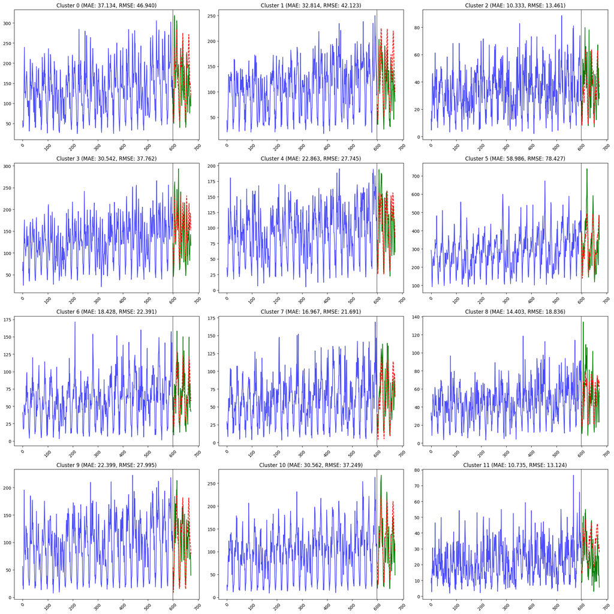

```python
plot_forecasts(cv_results, cluster_dfs)
```

## Simulate inference

This shows how the predictions help drivers. Given where a driver is now, it suggests the best zones to head to—closer ones with lots of rides get priority. It’s like a ride-finding assistant.

```python
from geopy.distance import geodesic
from scipy.special import softmax


def weight_ride_values_softmax(
    current_position, locations, expected_ride_values, temperature=1.0
):
    """
    Weight expected ride values based on distance from current position using softmax.

    Parameters:
    current_position (array): [latitude, longitude] of current position
    locations (list): List of [latitude, longitude] arrays for potential rides
    expected_ride_values (list): Expected value for each ride location
    temperature (float): Controls the "temperature" of softmax distribution
                         Lower values make distribution more peaked (more sensitive to distance)
                         Higher values make distribution more uniform

    Returns:
    weighted_values (list): Distance-weighted ride values using softmax
    """
    # Calculate distances
    distances = []
    for location in locations:
        dist = geodesic(
            (current_position[0], current_position[1]), (location[0], location[1])
        ).kilometers
        distances.append(dist)

    # Convert to numpy array
    distances = np.array(distances)
    # Invert distances (smaller distances should have higher weights)
    # Adding a small epsilon to avoid division by zero
    inverse_distances = 1 / (distances + 1e-10)

    # Apply softmax to get probability distribution
    # Dividing by temperature to control the "peakiness" of distribution
    weights = softmax(inverse_distances / temperature)
    weighted_values = weights * np.array(expected_ride_values)
    return weighted_values


def forecast(curr_datetime, future_steps, cluster_idx, train_last_date, model_dir):
    # Load the model
    with open(f"{model_dir}/cluster{cluster_idx}_arima.pkl", "rb") as f:
        model = pickle.load(f)

    # Check if current datetime is after the last training datetime
    if curr_datetime <= train_last_date:
        return "Cannot forecast for past or current time"

    steps = (curr_datetime - train_last_date).days + future_steps
    # Forecast
    forecast = model.forecast(steps=steps)
    return sum(forecast[-future_steps:]) / future_steps
```

```python
dir_pth = "models/baseline_cv"
curr_datetime = pd.to_datetime("2022-05-01 00:00:00")
curr_lat, curr_lng = df["start_lat"].mean(), df["start_lng"].mean()
print(f"Current datetime: {curr_datetime}")
print(f"Current location: Lat {curr_lat:.6f}, Lng {curr_lng:.6f}")


def inference(
    curr_datetime, future_steps, topk, centers, cluster_train_last_dates, dir_pth
):
    prediction = [
        forecast(
            curr_datetime,
            future_steps,
            cluster_idx,
            cluster_train_last_dates[cluster_idx],
            dir_pth,
        )
        for cluster_idx in range(n_clusters)
    ]
    wrv = weight_ride_values_softmax((curr_lat, curr_lng), centers, prediction, 1)
    topk = np.argsort(wrv)[-topk:]
    top_loc = [centers[cluster_idx] for cluster_idx in topk]
    top_pred = [prediction[cluster_idx] for cluster_idx in topk]
    return top_loc, top_pred


# Load last_train_dates json
cluster_train_last_dates = load_train_last_date(dir_pth)
future_steps = 1
topk = 5

top_locations, top_prediction = inference(
    curr_datetime, future_steps, topk, centers, cluster_train_last_dates, dir_pth
)
print("Top Locations:")
for loc, pred in zip(top_locations, top_prediction):
    print(f"Location: Lat {loc[0]:.6f}, Lng {loc[1]:.6f} - Predicted Value: {pred:.2f}")
```

```
Current datetime: 2022-05-01 00:00:00
Current location: Lat 59.428684, Lng 24.743476
Top Locations:
Location: Lat 59.404730, Lng 24.707919 - Predicted Value: 128.33
Location: Lat 59.428194, Lng 24.803944 - Predicted Value: 155.05
Location: Lat 59.443716, Lng 24.721274 - Predicted Value: 146.92
Location: Lat 59.423885, Lng 24.726626 - Predicted Value: 201.50
Location: Lat 59.435231, Lng 24.757556 - Predicted Value: 276.03
```

## Overall Conclusion

I built a system to guide drivers to busy spots in Tallinn using zones and predictions. It’s a good start—drivers earn more, riders wait less.

**Conclusion:** This solution matches drivers to demand in real-time, using 12 zones and hourly forecasts. It’s practical for Bolt and could improve with more data like traffic or events.

## Ride-Hailing Demand Prediction System Report

### 1. Data Exploration and Solution Approach

My existing code covers:

- Data cleaning (removing missing values, duplicates, outliers)
- Exploratory data analysis (EDA) with visualizations
- Coordinate clustering to identify key locations
- Time series analysis of ride values by cluster

#### Key Insights:

- Temporal patterns exist by hour of day and day of week
- K-means clustering effectively identifies high-demand areas
- Forecasting models can predict future demand by location

### 2. Baseline Model Solution

#### Baseline Model Documentation

The baseline solution uses a two-stage approach:

1. **Spatial Clustering**: Using K-means to identify high-demand geographical zones
2. **Time Series Forecasting**: ARIMA models for each cluster to predict future demand

**Model Performance**:

- Cross-validation was used to find optimal ARIMA parameters
- Models were evaluated using MAE and RMSE metrics
- Forecast visualizations show reasonable prediction accuracy

**Inference Workflow**:

- The model provides actionable predictions through these steps:
  1. Receive current driver location and timestamp
  2. Generate demand forecasts for each cluster using ARIMA models
  3. Weight predictions by distance using softmax function
  4. Rank and recommend optimal locations to drivers

**Strengths**:

- Captures both spatial and temporal patterns
- Provides location-specific predictions
- Uses established time series methods
- Relatively simple to implement and interpret

**Limitations**:

- Does not incorporate external factors (weather, events)
- Limited to historical patterns

### 3. Model Design and Deployment

#### AWS-Based System Architecture

```
┌─────────────┐     ┌─────────────┐     ┌─────────────┐
│             │     │             │     │             │
│   Amazon    │────▶│   Amazon    │────▶│     API     │
│     S3      │     │     EC2     │     │   Gateway   │
│             │     │ (Training)  │     │             │
└─────────────┘     └─────────────┘     └─────────────┘
       ▲                   │                   │
       │                   │                   ▼
       │                   │            ┌─────────────┐
┌─────────────┐            │            │             │
│             │            │            │    AWS      │
│  Ride Data  │            └───────────▶│   Lambda    │
│  Collection │                         │ (Inference) │
└─────────────┘                         └─────────────┘
      │
      ▼
┌─────────────┐
│             │
│ CloudWatch  │
│ Monitoring  │
│             │
└─────────────┘
```

**1. Data Storage (Amazon S3)**

- Historical and new ride data are stored in S3 buckets.
- Daily CSV exports from "Ride Data Collection" (e.g., app backend) are uploaded to S3 automatically.

**2. Model Training (Amazon EC2)**

- A small EC2 instance runs a Python script weekly to:
  - Load historical data from S3.
  - Train an ARIMA model for each geographical cluster.
  - Save trained models back to S3 as pickled files.

**3. Prediction Service (Lambda + API Gateway)**

- The driver app calls an API Gateway endpoint with the driver’s current location and timestamp.
- API Gateway triggers a Lambda function that:
  - Loads pre-trained ARIMA models from S3.
  - Generates demand forecasts for each cluster.
  - Weights predictions by distance using a softmax function.
  - Returns ranked cluster recommendations in <1 second.

### 4. Driver Communication Strategy

1. **In-App Map Interface**
   - Displays a heatmap of predicted demand by cluster.
   - Uses simple colors: red for high demand, blue for low demand.
   - Updates hourly to keep drivers informed without overload.
2. **Push Notifications**
   - Sends personalized alerts based on driver location.
   - Limited to 1-2 per hour to avoid annoyance.
3. **Earnings Focus**
   - Highlights top clusters by predicted hourly revenue.
   - Helps drivers prioritize areas with stable earnings potential.

### 5. Experiment Design for Validation

- **Objective**: Test if demand predictions increase driver earnings and reduce rider wait times, validated through phased deployment.
- **Setup**:
  - **Phase A (Small-Scale Test)**: Start with 50 drivers in one Tallinn district. Split into 25 control (no guidance, current system) and 25 treatment (using prediction tool) for 1 week to test feasibility.
  - **Phase B (Regional Expansion)**: Scale to 500 drivers in central Tallinn, with 250 control and 250 treatment, for 2 weeks to capture weekly patterns and refine the model.
  - **Phase C (Total Deployment)**: Expand to all Tallinn drivers (e.g., 1000+), fully deploying the prediction tool for 4 weeks, transitioning from test to full operations.
- **Safety Measures**:
  - Monitor hourly; pause if wait times rise >10% in any cluster.
  - Ensure no area loses all drivers by tracking ride coverage.
- **Key Metrics**:
  - **Driver Earnings**: Average hourly revenue (€/hour).
  - **Rider Wait Time**: Median time from request to pickup (minutes).
  - **Ride Completion Rate**: % of requests fulfilled.
- **Analysis Focus**:
  - Compare metrics between control and treatment groups in Phase A and B (e.g., €/hour difference).
  - Check peak hours (e.g., 8 AM) vs. off-peak (e.g., 2 AM).
  - In Phase C, assess city-wide scalability and long-term trends.
- **Feedback**:
  - Weekly driver surveys (e.g., "Did recommendations help?") in Phases A and B to refine the tool..
  - Adjust based on issues (e.g., tweak notification timing) before Phase C rollout..

## Describe what additional data would you consider useful

To guide drivers to high-demand areas using Driver Location (distance to pickup), Weather (sunny/rainy/snowy), and Traffic Condition

A LightGBM-based RegressionModel in Darts might be a promising—flexible model selection, it can train on historical data and, at inference, predict value for each cluster_loc given current driver_loc, time, and weather, enabling effective driver recommendations in Tallinn’s ride-hailing system.